# CAS - Seminární práce

Eliška Junková, Matěj Sloup

2025-09-21

## 1. **Grafické zobrazení řady, komentář dat**

Analyzovaná data obsahují návštevnost a tržby městského bazénu. Řada obsahuje denní data za roky 2023 a 2024. Data budeme zkoumat v časovém rámci roku. Naší hlavní řadou bude návštěvnost, vedlejší řadou bude tržba.

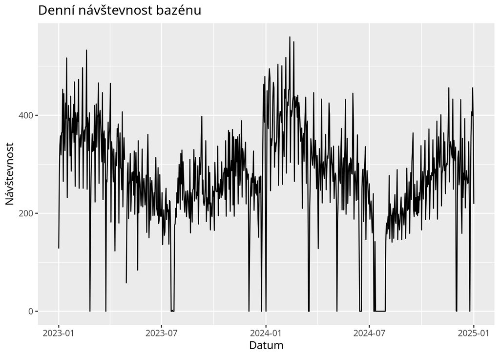

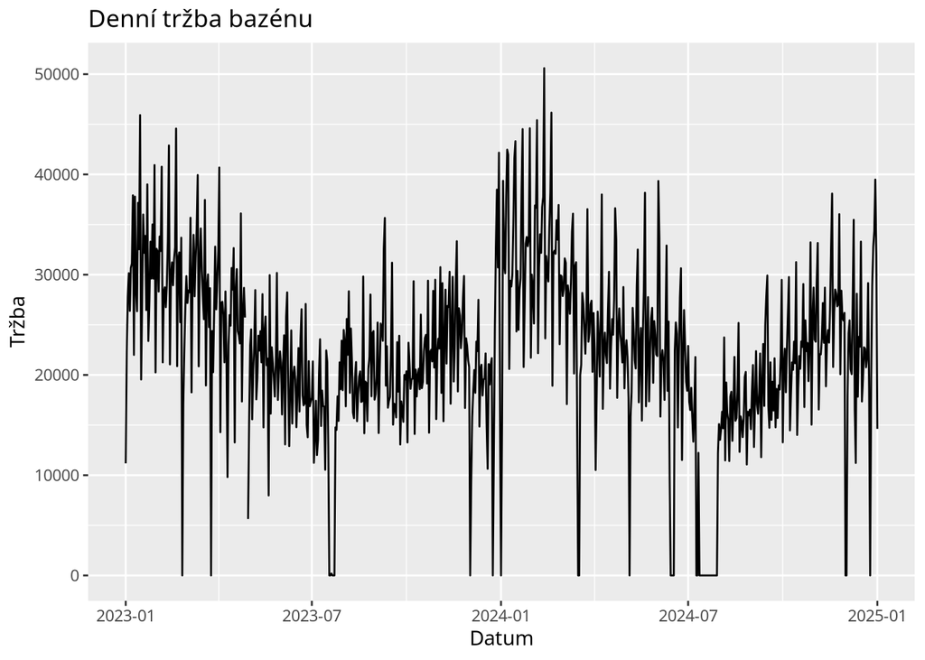

I když tento fakt není moc viditelný, řada obsahuje nulové a prázdné hodnoty. Tyto hodnoty jsou způsobeny dny, kdy bazén byl uzavřen/vyhrazen pro nějaké akce a odstávky systému, v tomto pořadí. Pro naše účely v některých případech budou chybějící hodnoty nahrazeny nulami. Data ukazují jasnou sezónnost, konstantně vypadající trend.

## 2. Dekompozice a idenfikace trendu pomocí vyhlazení řady

### Klouzavé průměry

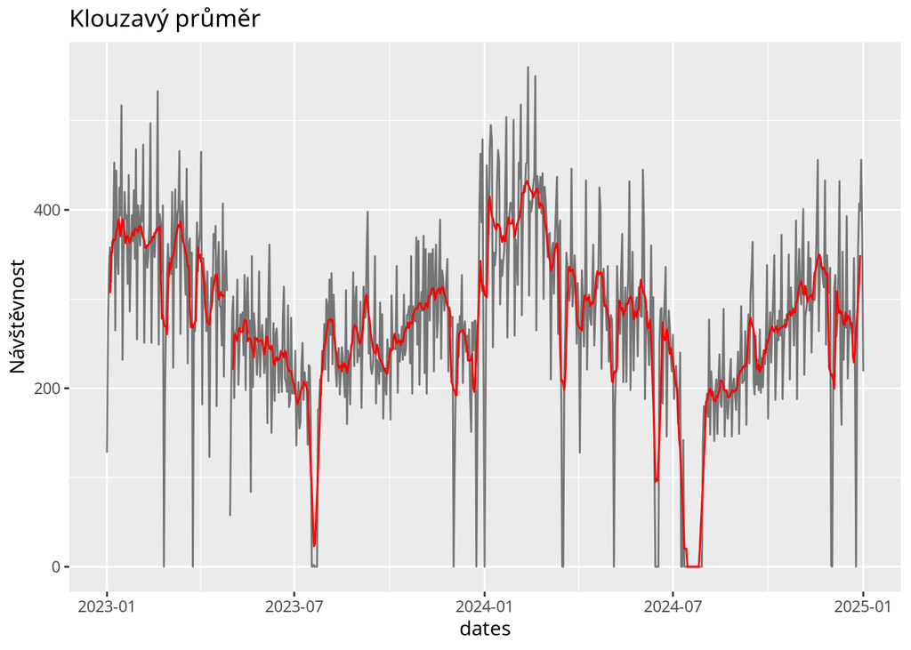

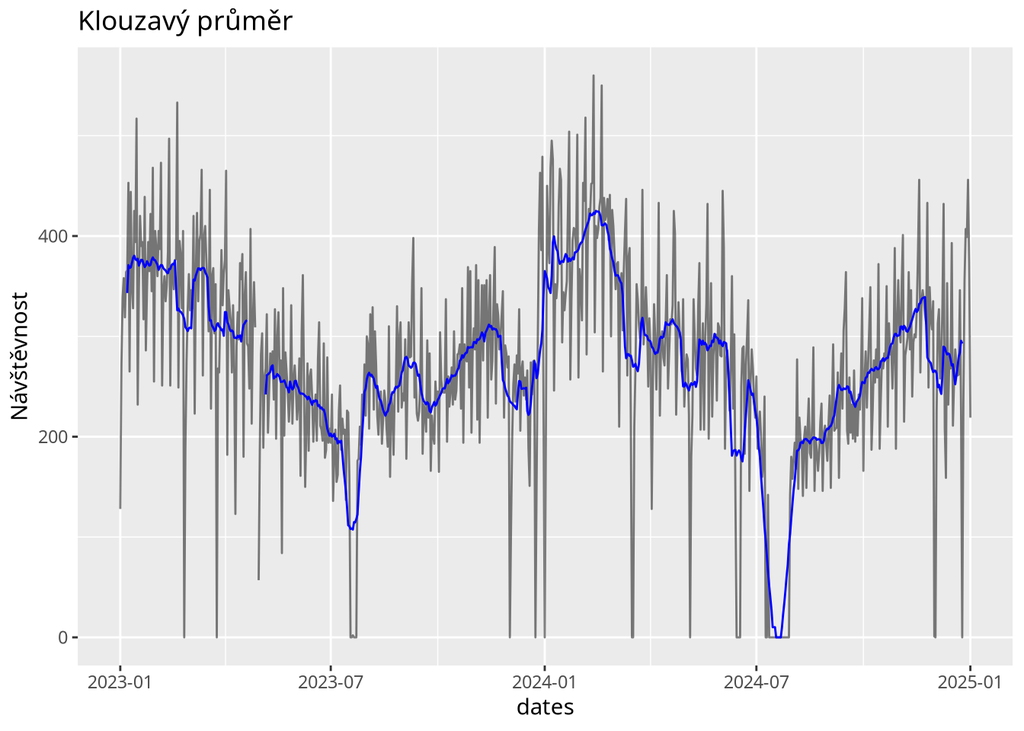

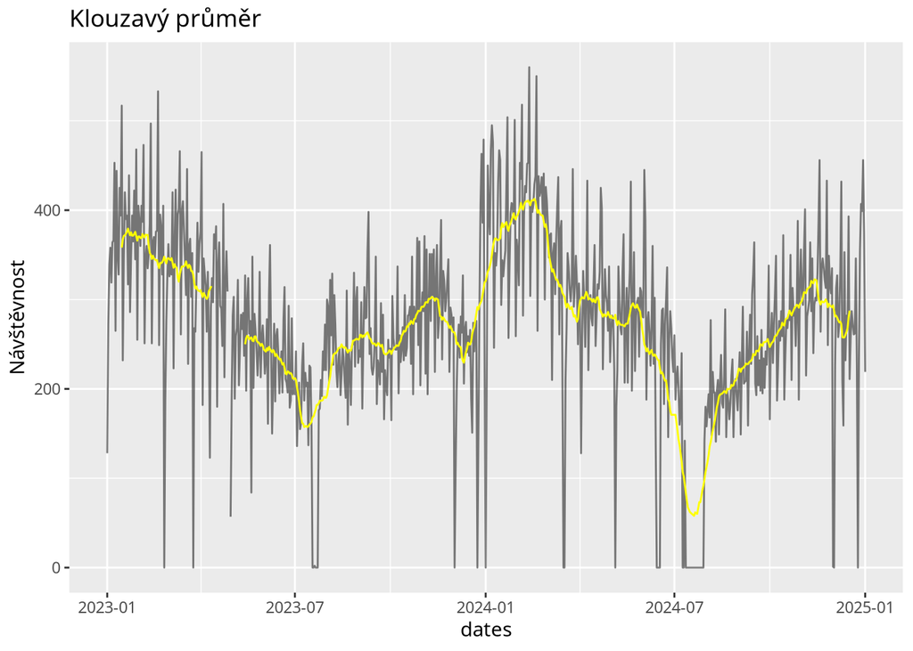

Sedmidenní klouzavý průměr neposkytuje dostatečné vyhlazení, zatímco třicetidenní poskytuje moc agresivní vyhlazení. Čtrnáctidenní vyhlazení vypadá jako optimum. Nulové hodnoty trochu skreslují výsledek. V datech lze vidět sezónnost na úrovni roku.

### Exponenciální vyrovnání

```
##              Length Class  Mode
## fitted       1468   mts    numeric
## x             732   ts     numeric
## alpha           1   -none- numeric
## beta            1   -none- numeric
## gamma           1   -none- numeric
## coefficients  367   -none- numeric
## seasonal        1   -none- character
## SSE             1   -none- numeric
## call            2   -none- call
```

```
##     alpha
## 0.3635206
```

```
## beta
##    0
```

```
## gamma
##     1
```

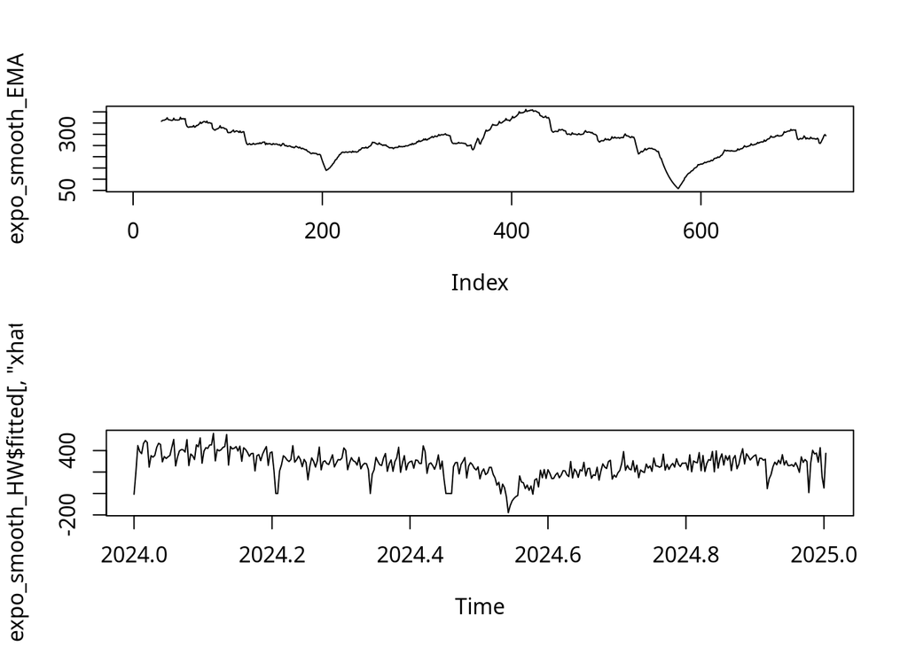

Exponenciální vyrovnání pomocí funkce EMA je celkem kolísavé. Parametry Holt-Wintersovy metody jsou: - alfa: 0.3635206 - beta: 0 - gamma: 1

Toto nám říká, že podle Holt-Wintersovy metody je trend konstatní, a řada obsahuje sezónnost. Nulová beta značí konstantní trend, a gamma na hodnotě 1 značí silnou sezónnost.

## 3. Optimální modely pro řadu

### Funkční zápis

```
## [1] 0.2036347
```

```
## [1] 0.02609348
```

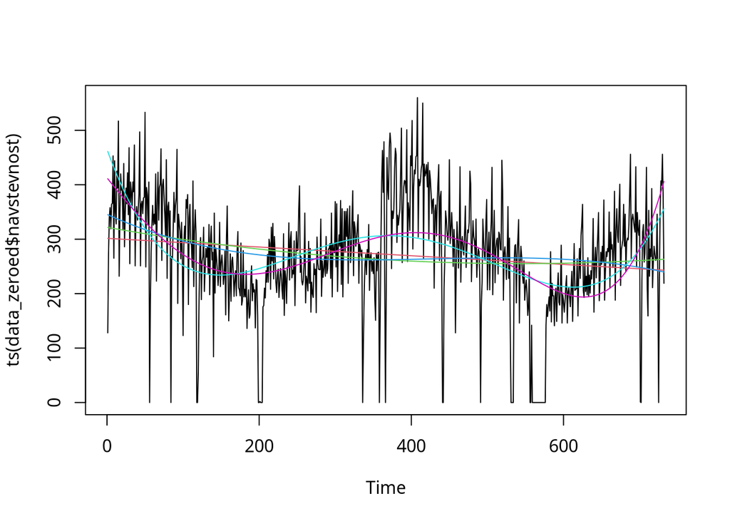

```
## [1] 8884.462
```

```
## [1] 8885.455
```

```
## [1] 8886.53
```

```
## [1] 8776.674
```

```
## [1] 8763.524
```

Nejlépe vypadající trend je u polynomu stupně 5, nicméně kritérium r^2 napovídá, že tato křivka nevysvětluje velkou část residuí. Je možné že vyšší polynomiální stupeň bude křivku vystihovat ještě lépe, nicméně nárust v přesnosti bude logaritmický. Stupeň 5 postačí. Pozoruhodné ještě je, že kritéria BIC lineární model je lepší než kvadratický a kubický.

### Loess model

```
##  Call:
##  stl(x = ts_navs_zero, s.window = "periodic")
##
##  Time.series components:
##     seasonal              trend            remainder
##  Min.   :-274.15713   Min.   :264.5036   Min.   :-195.38418
##  1st Qu.: -61.42071   1st Qu.:269.5713   1st Qu.: -19.99489
##  Median :   2.81245   Median :271.6094   Median :   0.25912
##  Mean   :  -0.19489   Mean   :272.2501   Mean   :   0.25352
##  3rd Qu.:  61.90248   3rd Qu.:274.9405   3rd Qu.:  20.81481
##  Max.   : 270.70239   Max.   :278.5305   Max.   : 204.82990
##  IQR:
##      STL.seasonal STL.trend STL.remainder data
##      123.323        5.369    40.810       119.250
##    % 103.4          4.5      34.2         100.0
##
##  Weights: all == 1
##
##  Other components: List of 5
##  $ win  : Named num [1:3] 7321 549 365
##  $ deg  : Named int [1:3] 0 1 1
##  $ jump : Named num [1:3] 733 55 37
##  $ inner: int 2
##  $ outer: int 0
```

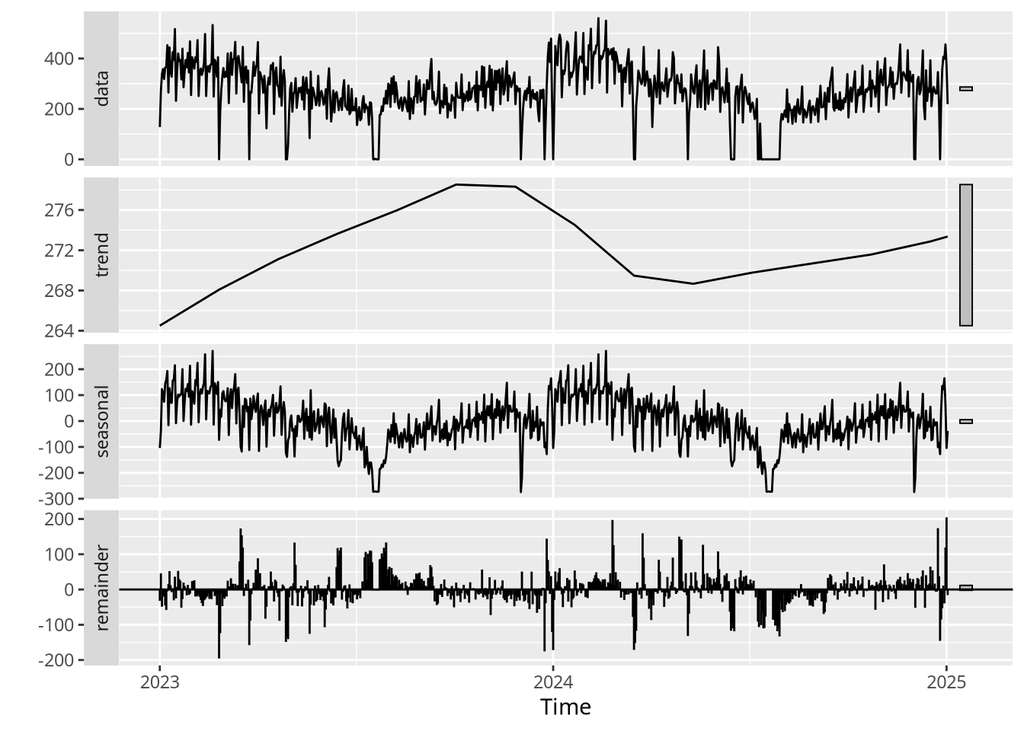

Loess potvrzuje sezónnost, ale narozdíl od Holt-Wintersovy metody promítá kladný, nekonstantní trend.

## 4. Sarima model

```
## Series: ts_navs_full
## ARIMA(1,0,0)(0,1,0)[365]
##
## Coefficients:
##          ar1
##       0.5488
## s.e.  0.0440
##
## sigma^2 = 6155:  log likelihood = -2110.06
## AIC=4224.12   AICc=4224.15   BIC=4231.93
##
## Training set error measures:
##                      ME     RMSE      MAE MPE MAPE      MASE         ACF1
## Training set -0.7753245 55.39767 26.39543 NaN  Inf 0.4191938 -0.007286574
```

```
## Series: ts_navs_full
## ARIMA(1,0,0)(0,1,0)[365]
##
## Coefficients:
##          ar1
##       0.5488
## s.e.  0.0440
##
## sigma^2 = 6155:  log likelihood = -2110.06
## AIC=4224.12   AICc=4224.15   BIC=4231.93
##
## Training set error measures:
##                      ME     RMSE      MAE MPE MAPE      MASE         ACF1
## Training set -0.7753245 55.39767 26.39543 NaN  Inf 0.4191938 -0.007286574
```

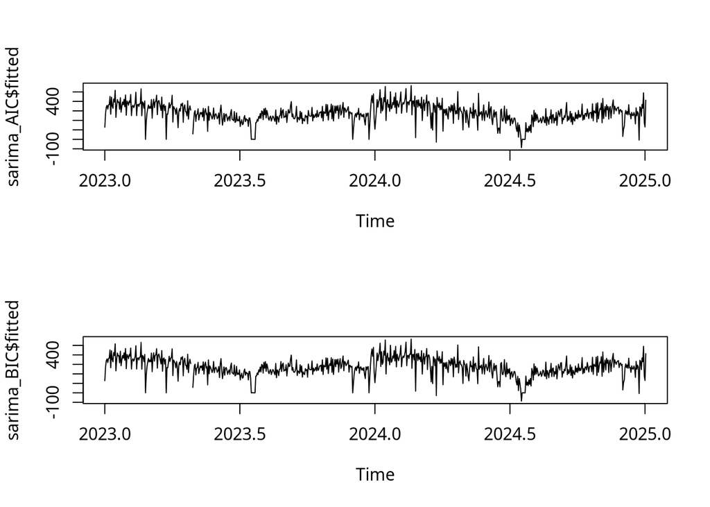

Volba podle AIC i BIC nám automaticky zvolí SARIMA model (1,0,0)(0,1,0)[365]. Toto znamená následující: - Hodnota autoregrese je 1, což znamená že se využívá pouze hodnota předchozího kroku. - Řada není diferencována, tudíž již je stacionární. - Řadu je nutno sezónně diferencovat, tudíž máme další důkaz sezónnosti.

## 5. ** Závislosti na jiných řadách, dynamické modely **

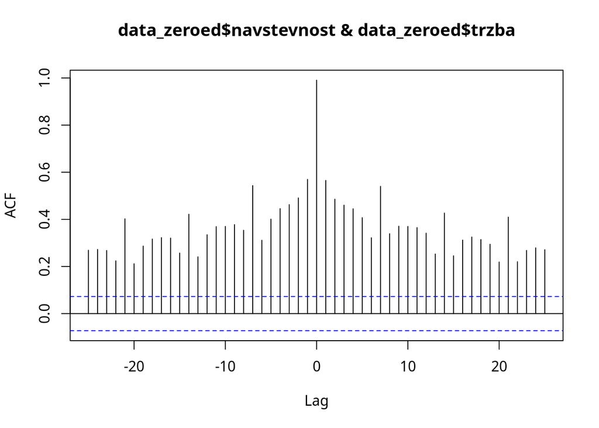

Vzhledem k tomu že kroskorelační funkce nabývá hodnoty 1 v lagu 0, znamená že mezi návštěvností a tržbou bude nějaká korelace. Selský rozum by nám asi napověděl, že by tam mohla být pozitivní lineární závislost.

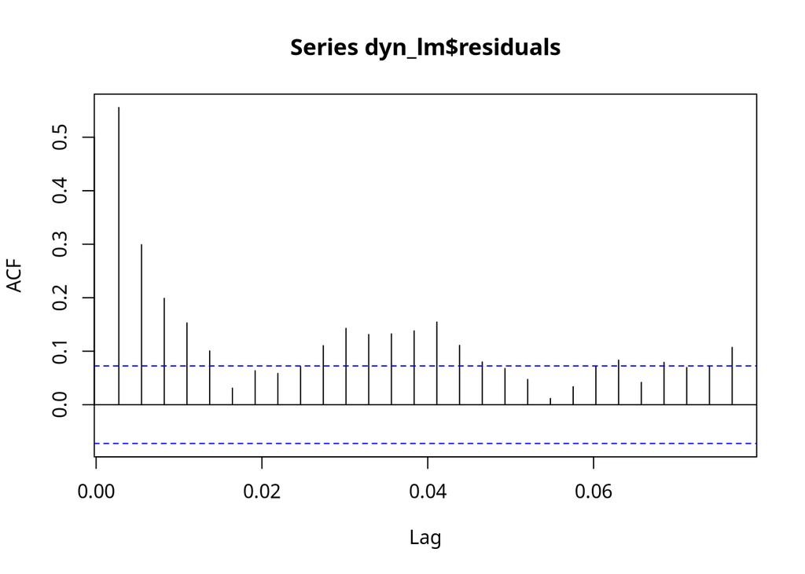

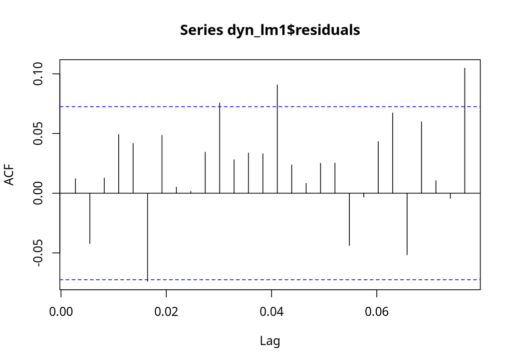

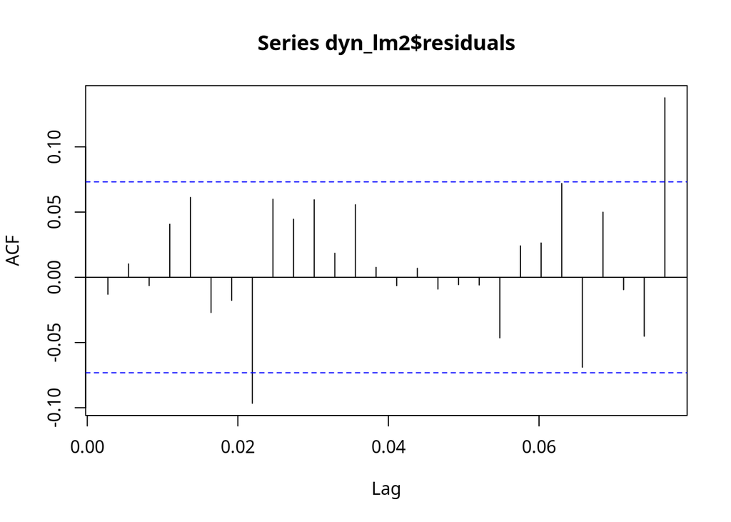

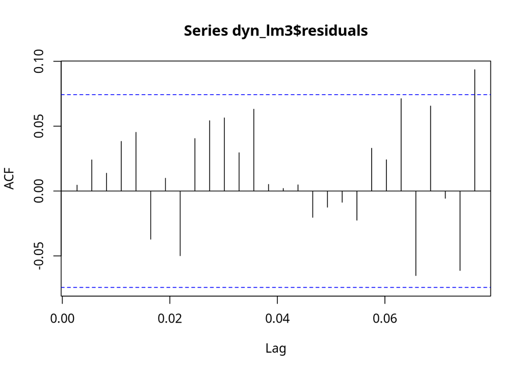

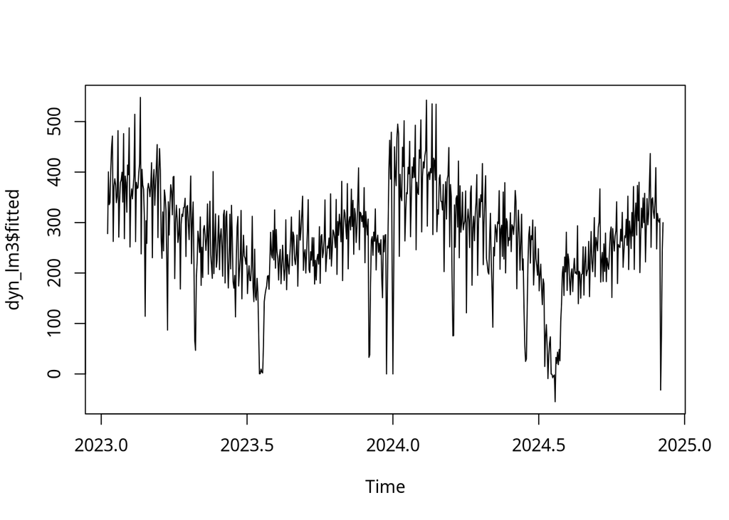

## 6. **Analýza residuí**

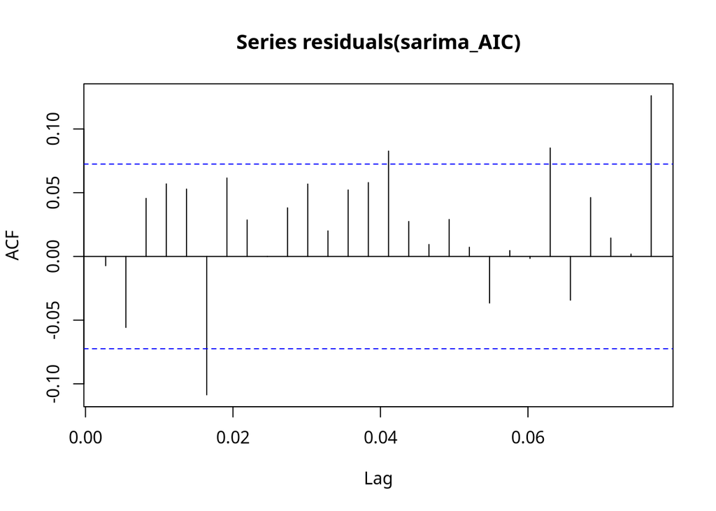

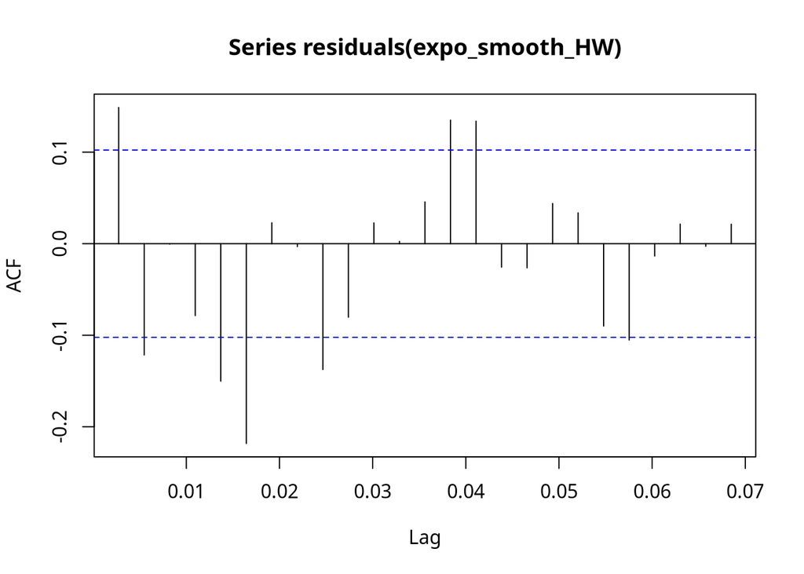

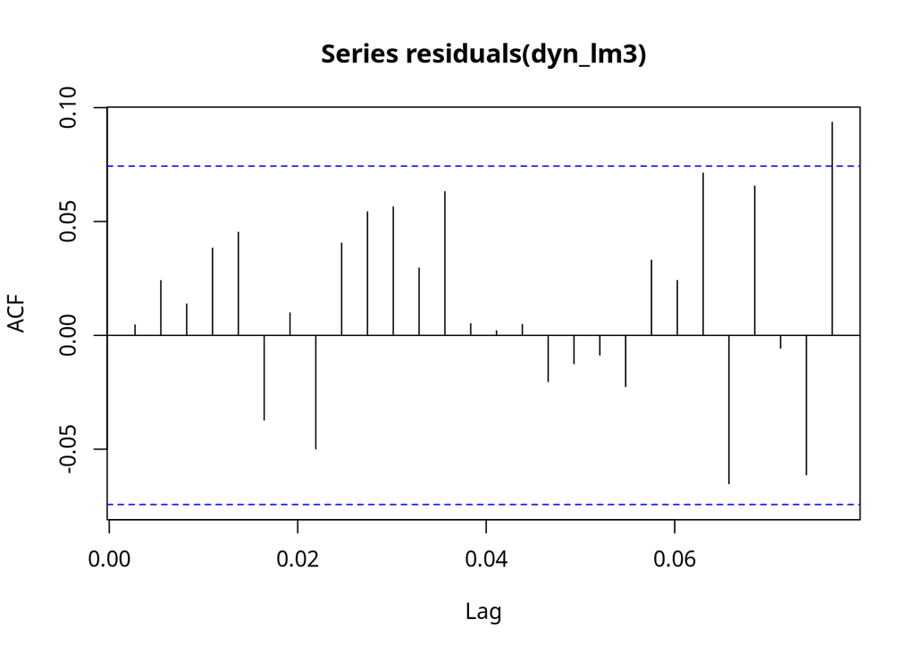

Residua mírně přesahují akceptovatelný interval, nicméně nevím co s tím udělat, a doufám ve známku 3 a nic lepšího, takže budu doufat že zbytek bude stačit, protože fakt nemám čas to řešit

## 7. **Predikce**

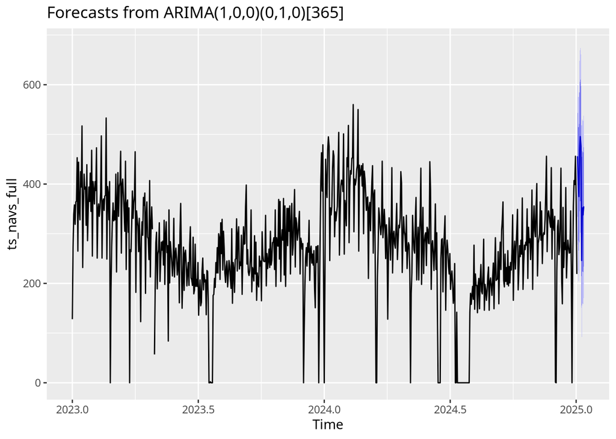

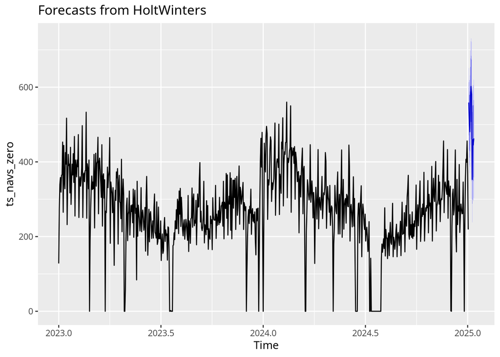

Sarima předpovídá celkem smysluplně. Holt-Winters model vypadá relativně problémově.